# NEW YORK CITY TAXI DATA ANALYSIS

##### Consistent fares across bin (100-250)

```python
trip_std_of_fare_amt_per_unit_dist[(trip_std_of_fare_amt_per_unit_dist.binned==pd.Interval(100,250)) & (trip_std_of_fare_amt_per_unit_dist['size']>100)].sort_values(by='std')
```

|  | pickup_longitude | pickup_latitude | dropoff_longitude | dropoff_latitude | size | std | binned |
| --- | --- | --- | --- | --- | --- | --- | --- |
| 11517977 | -73.965012 | 40.755657 | -73.965012 | 40.755657 | 128 | 2.186908 | (0, 250] |
| 824 | -74.195213 | 40.548466 | -74.195213 | 40.548466 | 155 | 2.286842 | (0, 250] |
| 14696826 | 0.000000 | 41.453693 | 0.000000 | 41.453693 | 103 | 2.395854 | (0, 250] |
| 14140555 | -73.883629 | 40.632210 | -73.883629 | 40.632210 | 238 | 2.768827 | (0, 250] |

##### Consistent fares across bin (250-500)

```python
trip_std_of_fare_amt_per_unit_dist[(trip_std_of_fare_amt_per_unit_dist.binned==pd.Interval(250,500)) & (trip_std_of_fare_amt_per_unit_dist['size']>=250)].sort_values(by='std')
```

|  | pickup_longitude | pickup_latitude | dropoff_longitude | dropoff_latitude | size | std | binned |
| --- | --- | --- | --- | --- | --- | --- | --- |
| 14082906 | -73.917358 | 40.670559 | -73.917358 | 40.670559 | 390 | 0.0 | (250, 500] |

##### Consistent fares across bin (750-1000)

```python
trip_std_of_fare_amt_per_unit_dist[(trip_std_of_fare_amt_per_unit_dist.binned==pd.Interval(750,1000)) & (trip_std_of_fare_amt_per_unit_dist['size']>=750)].sort_values(by='std')
```

|  | pickup_longitude | pickup_latitude | dropoff_longitude | dropoff_latitude | size | std | binned |
| --- | --- | --- | --- | --- | --- | --- | --- |
| 4196033 | -73.990944 | 40.736053 | -73.990944 | 40.736053 | 848 | 2.541199 | (750, 1000] |
| 13646532 | -73.949043 | 40.744915 | -73.949043 | 40.744915 | 843 | 3.473430 | (750, 1000] |

##### Consistent fares across bin (1000-10000)

```python
trip_std_of_fare_amt_per_unit_dist[(trip_std_of_fare_amt_per_unit_dist.binned==pd.Interval(1000,10000)) & (trip_std_of_fare_amt_per_unit_dist['size']>=1000)].sort_values(by='std')
```

|  | pickup_longitude | pickup_latitude | dropoff_longitude | dropoff_latitude | size | std | binned |
| --- | --- | --- | --- | --- | --- | --- | --- |
| 7528 | -74.023048 | 40.765991 | -74.023048 | 40.765991 | 6818 | 0.0 | (1000, 10000] |

# PART B : Open Questions

### a. In what trips can you confidently use respective means as measures of central tendency to estimate fare, time taken, etc.

#### Step 1: Plot the distribution of each attribute of a trip

- Fare : *USE BASIC QN D TO ANSWER THIS*
- Fare per second
- Fare per unit distanced
- trip duration (travel time) : *USE BASIC QN C TO ANSWER THIS*
- distance
- Passenger Count
- Total Amount
- tip_amount (highly skewed towards 0.0 tip) -- Exlpore based on type of trip (negotiated fare / standard fare etc.)
- INSIGHT: THEY ARE ALL SKEWED

### Distribution of Fare Amount

```
Text(0.5,1,'Distribution of Trip Fare')
```

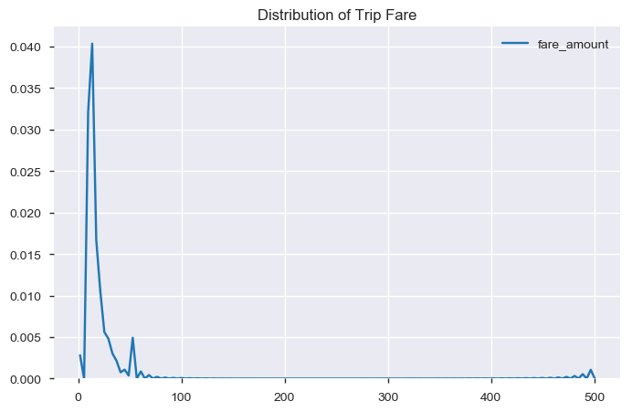

```python
plt.figure(figsize=(8,5))
sns.kdeplot(trip['fare_amount']).set_title("Distribution of Trip Fare")
```

```
Text(0.5,1,'Distribution of fare amount (log scale)')
```

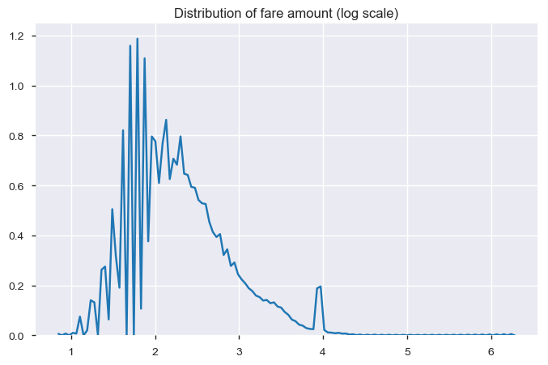

```python
plt.figure(figsize=(8,5))
sns.kdeplot(np.log(trip['fare_amount'].values)).set_title("Distribution of fare amount (log scale)")
```

### Distribution of Fare Per Unit Distance

```
Text(0.5,1,'Distribution of Trip Fare Per Unit Distance')
```

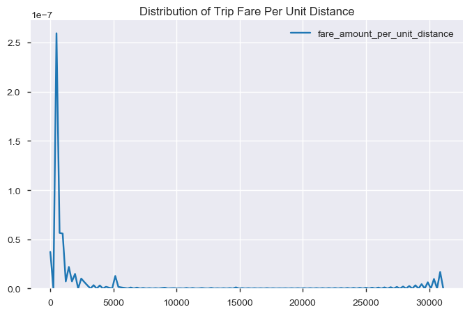

```python
plt.figure(figsize=(8,5))
sns.kdeplot(trip.fare_amount_per_unit_distance).set_title("Distribution of Trip Fare Per Unit Distance")
```

```
Text(0.5,1,'Distribution of Fare Per Unit Distance (log scale)')
```

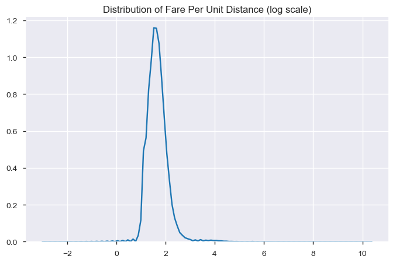

```python
plt.figure(figsize=(8,5))
sns.kdeplot(np.log(trip.fare_amount_per_unit_distance.values)).set_title("Distribution of Fare Per Unit Distance (log scale)")
```

### Dist of Fare Per Unit Time (Seconds)

```
Text(0.5,1,'Distribution of Trip Fare Per Second')
```

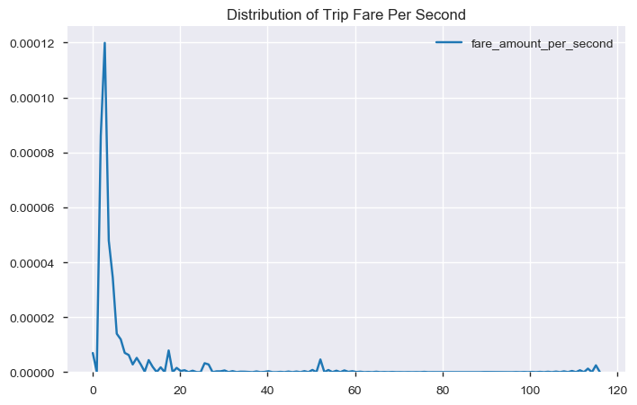

```python
plt.figure(figsize=(8,5))
sns.kdeplot(trip.fare_amount_per_second).set_title("Distribution of Trip Fare Per Second")
```

```
Text(0.5,1,'Distribution of Fare Per Second (log scale)')
```

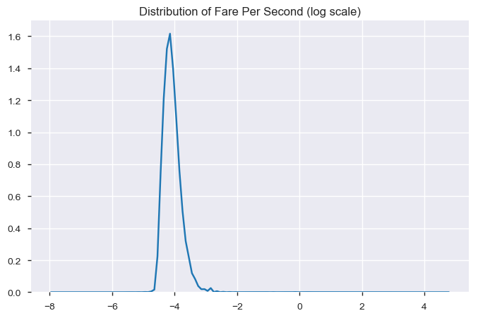

```python
plt.figure(figsize=(8,5))
sns.kdeplot(np.log(trip.fare_amount_per_second.values)).set_title("Distribution of Fare Per Second (log scale)")
```

### Dist of Trip Duration

```
Text(0.5,1,'Distribution of Trip Duration in Seconds')
```

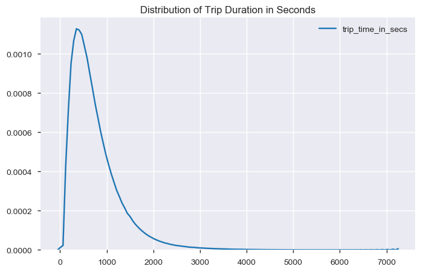

```python
plt.figure(figsize=(8,5))
sns.kdeplot(trip.trip_time_in_secs).set_title("Distribution of Trip Duration in Seconds")
```

```
Text(0.5,1,'Distribution of Trip Duration in Seconds')
```

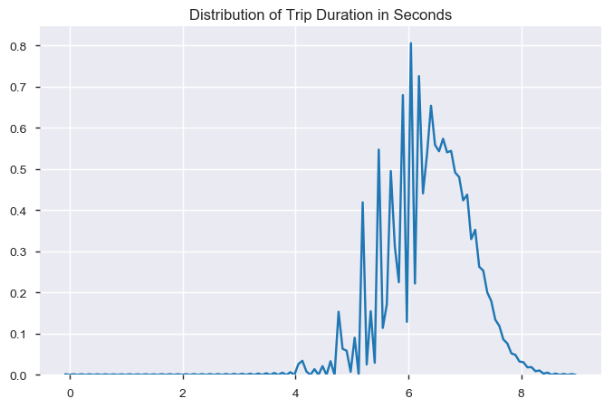

```python
plt.figure(figsize=(8,5))
sns.kdeplot(np.log(trip.trip_time_in_secs.values)).set_title("Distribution of Trip Duration in Seconds")
```

### Dist of Trip Distance

```
Text(0.5,1,'Distribution of Trip Distance')
```

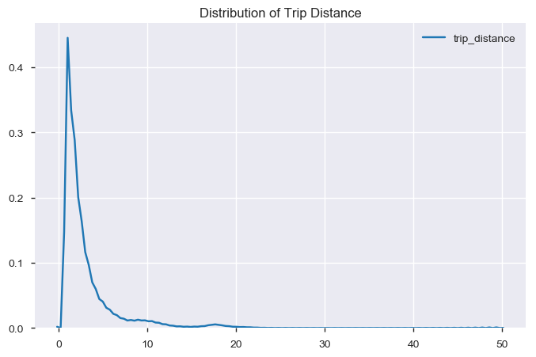

```python
plt.figure(figsize=(8,5))
sns.kdeplot(trip.trip_distance).set_title("Distribution of Trip Distance")
```

```
Text(0.5,1,'Distribution of Trip Distance (log scale)')
```

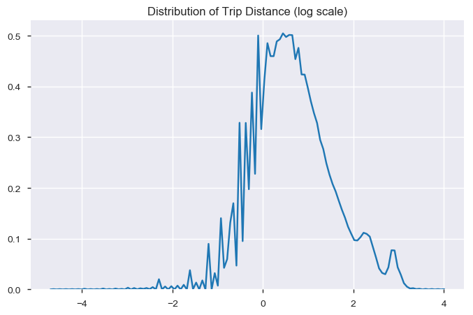

```python
plt.figure(figsize=(8,5))
sns.kdeplot(np.log(trip.trip_distance.values)).set_title("Distribution of Trip Distance (log scale)")
```

### Dist of Passenger Count

```
Text(0.5,1,'Distribution of Pax Count')
```

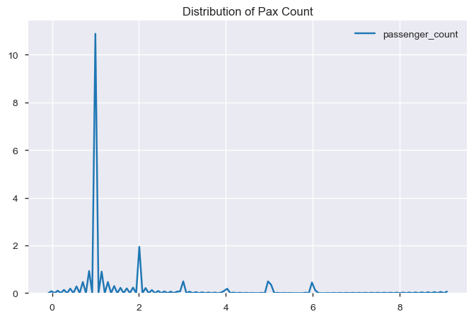

```python
plt.figure(figsize=(8,5))
sns.kdeplot(trip.passenger_count).set_title("Distribution of Pax Count")
```

```
Text(0.5,1,'Distribution of Pax Count(log scale)')
```

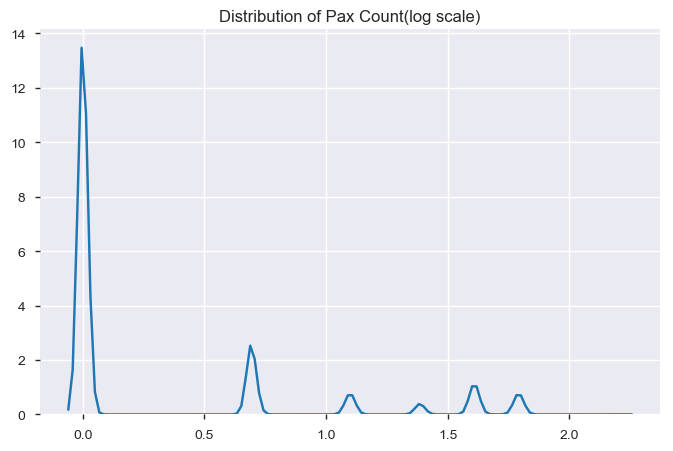

```python
plt.figure(figsize=(8,5))
sns.kdeplot(np.log(trip.passenger_count.values)).set_title("Distribution of Pax Count(log scale)")
```

### Distribution of Total Amount

```
Text(0.5,1,'Distribution of total_amount')
```

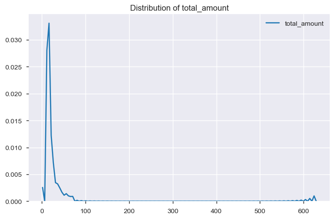

```python
plt.figure(figsize=(8,5))
sns.kdeplot(trip.total_amount).set_title("Distribution of total_amount")
```

```
Text(0.5,1,'Distribution of total_amount (log scale)')
```

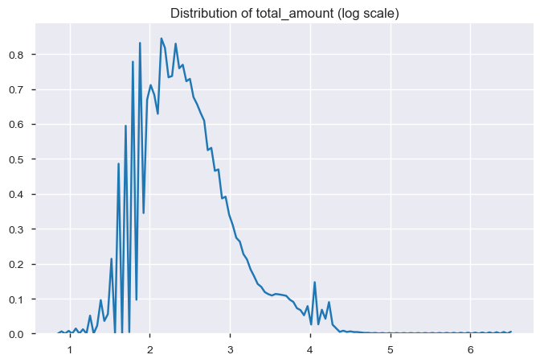

```python
plt.figure(figsize=(8,5))
sns.kdeplot(np.log(trip.total_amount.values)).set_title("Distribution of total_amount (log scale)")
```

### Distribution of Tip Amount

```
Text(0.5,1,'Distribution of tip_amount')
```

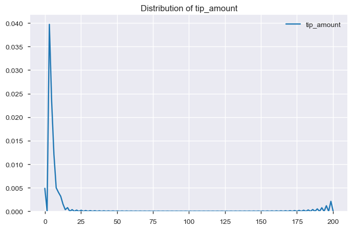

```python
plt.figure(figsize=(8,5))
sns.kdeplot(trip.tip_amount).set_title("Distribution of tip_amount")
```

```
Text(0.5,1,'Distribution of tip_amount (log scale)')
```

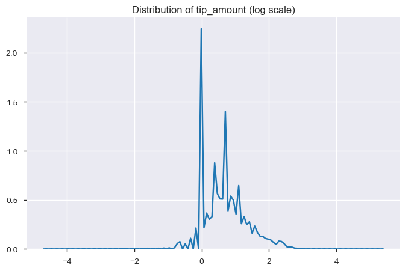

```python
plt.figure(figsize=(8,5))
sns.kdeplot(np.log(trip.tip_amount.values)).set_title("Distribution of tip_amount (log scale)")
```

## b. Can we build a model to predict fare and tip amount with the given data?

- We'll start by making a basic prediction model Linear regression and use only a few features that are strongly correlated to the target variable (fare / tip amt)

- From the correlation chart below, we can select a few features that are strongly linearly correlated to fare amount, namely "Trip time in seconds" , "Trip Distance" and "Rate Code"

```python
trip_baseline= pd.read_csv("trip_baseline.csv")
```

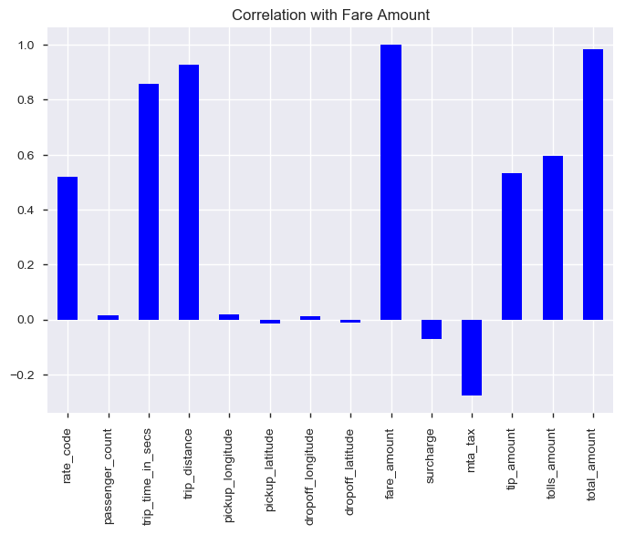

```python
corrs = trip_baseline.corr()
corrs['fare_amount'].plot.bar(color = 'b');
plt.title('Correlation with Fare Amount');
```

#### Subset Predictors variables athat are strongly correlated

```python
trip_baseline.columns
```

```
Index(['medallion', 'hack_license', 'vendor_id', 'rate_code',
       'store_and_fwd_flag', 'pickup_datetime', 'dropoff_datetime',
       'passenger_count', 'trip_time_in_secs', 'trip_distance',
       'pickup_longitude', 'pickup_latitude', 'dropoff_longitude',
       'dropoff_latitude', 'payment_type', 'fare_amount', 'surcharge',
       'mta_tax', 'tip_amount', 'tolls_amount', 'total_amount'],
      dtype='object')
```

```python
basic_model_fare_amt = trip_baseline[['rate_code','trip_time_in_secs','trip_distance','fare_amount']]
basic_model_fare_amt.head()
```

|  | rate_code | trip_time_in_secs | trip_distance | fare_amount |
| --- | --- | --- | --- | --- |
| 0 | 1 | 759 | 2.5 | 11.0 |
| 2 | 1 | 1318 | 3.6 | 16.5 |
| 3 | 1 | 799 | 1.9 | 10.0 |
| 4 | 1 | 1017 | 3.6 | 15.0 |
| 5 | 1 | 189 | 0.7 | 4.5 |

#### Removal of any nulls

```python
# No Null Values Present in columns
basic_model_fare_amt.isnull().sum()
```

```
rate_code            0
trip_time_in_secs    0
trip_distance        0
fare_amount          0
dtype: int64
```

#### Drop Duplicates

```python
print(basic_model_fare_amt.drop_duplicates(keep='first',inplace=True))
```

```
None
```